# Домашнее задание №5

Шаймарданов А.

06/12/2019

```r
library(mixOmics)
library(fossil)
load('/home/losashik/Downloads/brca.dat')
```

### Анализ датасета

Вначале посмотрим на датасет.

```r
str(data)
```

```
## List of 3
##  $ mRNA      : num [1:200, 1:150] 4.36 7.53 3.96 4.46 2.26 ...
##   ..- attr(*, "dimnames")=List of 2
##   .. ..$ : chr [1:200] "RTN2" "NDRG2" "CCDC113" "FAM63A" ...
##   .. ..$ : chr [1:150] "A0FJ" "A13E" "A0G0" "A0SX" ...
##  $ miRNA     : num [1:184, 1:150] 11.8 12.9 11.9 14.8 10.9 ...
##   ..- attr(*, "dimnames")=List of 2
##   .. ..$ : chr [1:184] "hsa-let-7a-1" "hsa-let-7a-2" "hsa-let-7a-3" "hsa-let-7b" ...
##   .. ..$ : chr [1:150] "A0FJ" "A13E" "A0G0" "A0SX" ...
##  $ proteomics: num [1:142, 1:150] 0.0491 0.4475 -0.0743 -0.3812 0.0261 ...
##   ..- attr(*, "dimnames")=List of 2
##   .. ..$ : chr [1:142] "14-3-3_epsilon" "4E-BP1" "4E-BP1_pS65" "4E-BP1_pT37" ...
##   .. ..$ : chr [1:150] "A0FJ" "A13E" "A0G0" "A0SX" ...
```

Видим, что у нас результаты трех экспериментов для каждой ткани в Y, а именно mRNA, miRNA и данные по протеомике. Проверим также, есть ли у нас где-нибудь NA. Вроде нет:

```r
sum(is.na(data$mRNA))
```

```
## [1] 0
```

```r
sum(is.na(data$miRNA))
```

```
## [1] 0
```

```r
sum(is.na(data$proteomics))
```

```
## [1] 0
```

Если говорить о нормализации, то данный датасет используется в туториале для mixOmics в котором [сказано](http://www.bioconductor.org/packages/release/bioc/vignettes/mixOmics/inst/doc/vignette.html#the-breast.tcga-study), что датасет уже предобработан.

Сначала попробуем клатсеризовать методом PCA.

### PCA

Делаю функцию для построения графиков:

```r
colours = c('red','green','blue')
figpca = function(pca, leg = 'PCA'){
dev = round(pca$sdev / sum(pca$sdev) * 100, 1)
plot(-pca$x[, 1], -pca$x[, 2], pch = 19,
     col = colours[as.integer(Y)], main = leg,
     xlab = paste0('PC1 (', dev[1], '%)'), ylab = paste0('PC2 (', dev[2], '%)'))
legend(legend = levels(Y), "bottomright",
       fill=colours)
}
```

Теперь сделаем PCA для mRNA

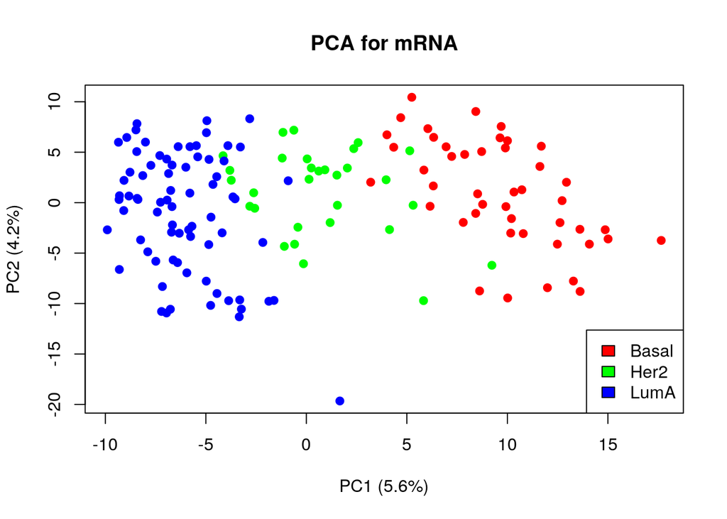

```r
pca_mRNA = prcomp(t(data$mRNA))
figpca(pca_mRNA, 'PCA for mRNA')
```

Для miRNA

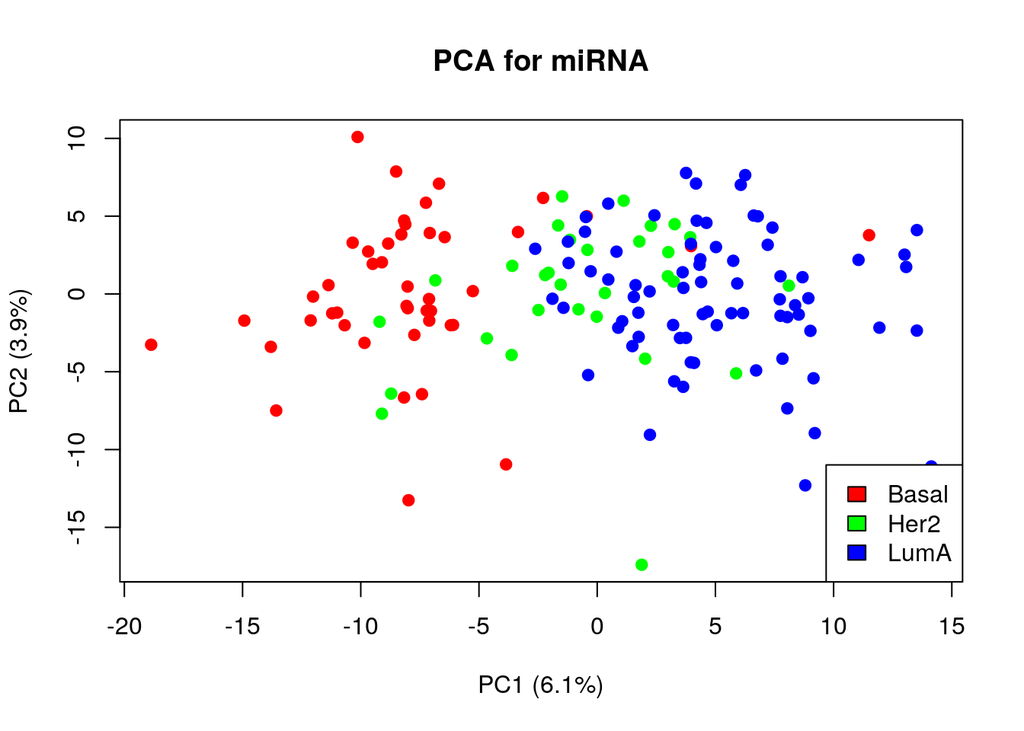

```r
pca_miRNA = prcomp(t(data$miRNA))
figpca(pca_miRNA, 'PCA for miRNA')
```

Для proteomics

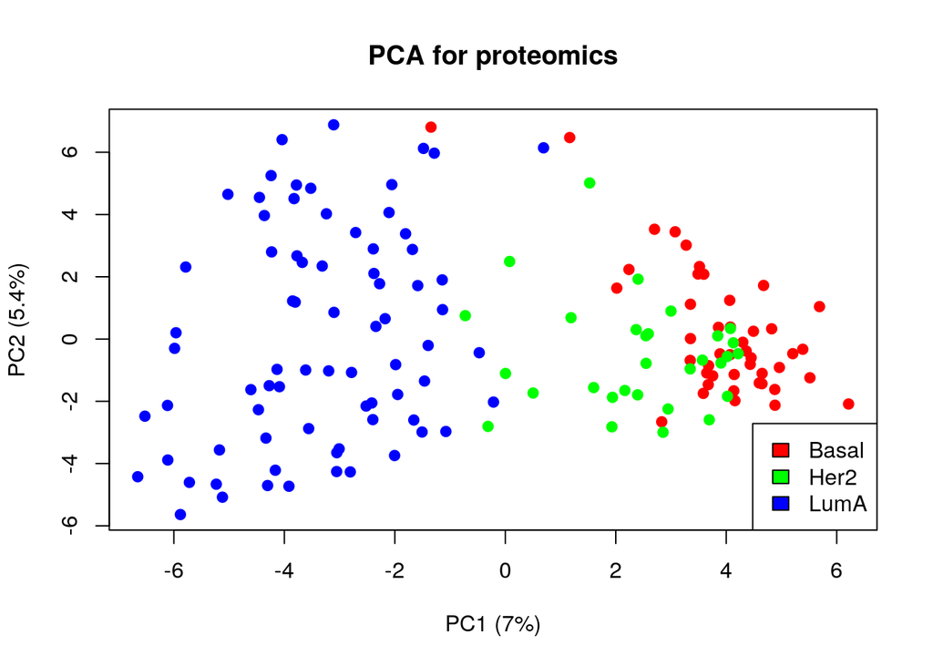

```r
pca_prot = prcomp(t(data$proteomics))
figpca(pca_prot, 'PCA for proteomics')
```

Как видим, что mRNA визуально поделилось неплохо, а для остальных могло бы быть и получше.

Посчитаем Rand index для каждого случая.

```r
ref = as.integer(Y)
names(ref) = colnames(data$mRNA)

res_pca_mRNA = kmeans(pca_mRNA$x, nstart = 100, centers = 3)
res_pca_miRNA = kmeans(pca_miRNA$x, nstart = 100, centers = 3)
res_pca_prot = kmeans(pca_prot$x, nstart = 100, centers = 3)
```

```r
rand.index(res_pca_mRNA$cluster, ref)
```

```
## [1] 0.7348546
```

```r
rand.index(res_pca_miRNA$cluster, ref)
```

```
## [1] 0.7104251
```

```r
rand.index(res_pca_prot$cluster, ref)
```

```
## [1] 0.7385235
```

### Иерархическая кластеризация

Попробуем воспользоваться ещё одним встроенным способом кластеризации, а именно иерархической. В качестве расстояния будем использовать корреляцию и также будем считать Rand index.

```r
rnd_hcl = function(data, leg){
  correlation = cor(data,method = 'spearman')
  plot(hclust(as.dist(1-correlation)), main = leg)
  hiercl = rect.hclust(hclust(as.dist(1-correlation)), k=3)
  cl1 = rep(1, length(hiercl[[1]]))
  names(cl1) = names(hiercl[[1]])
  cl2 = rep(2, length(hiercl[[2]]))
  names(cl2) = names(hiercl[[2]])
  cl3 = rep(3, length(hiercl[[3]]))
  names(cl3) = names(hiercl[[3]])
  cl = c(cl1,cl2,cl3)
  return(rand.index(cl, ref))
}
```

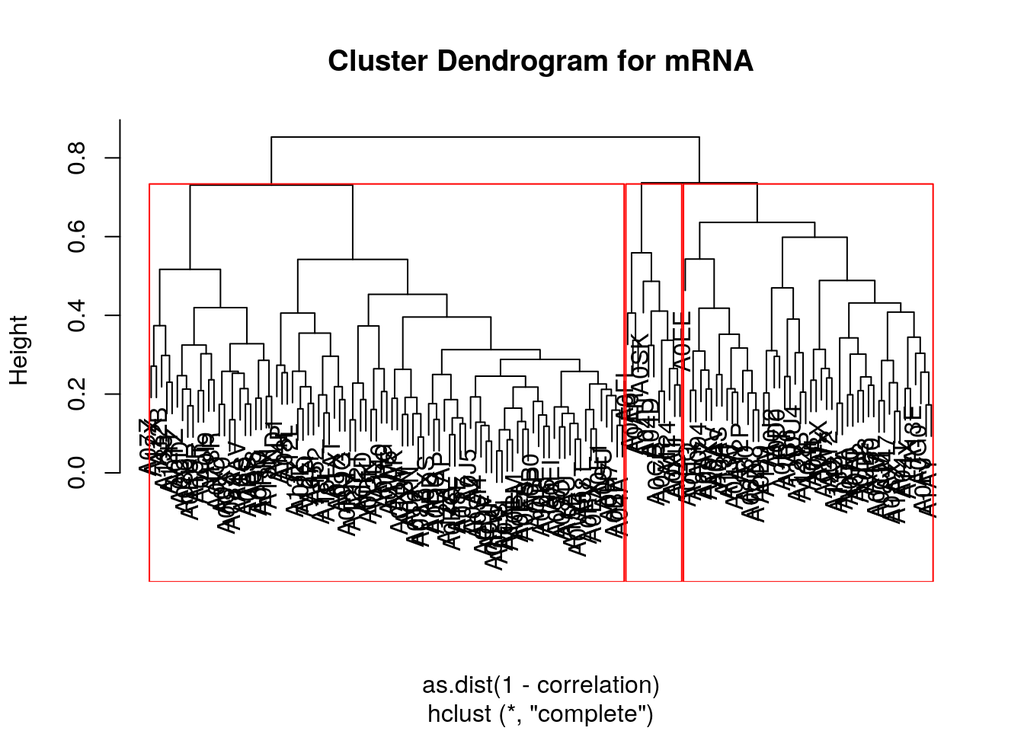

```
## [1] 0.6400895
```

```r
rnd_hcl(data$mRNA, 'Cluster Dendrogram for mRNA')
```

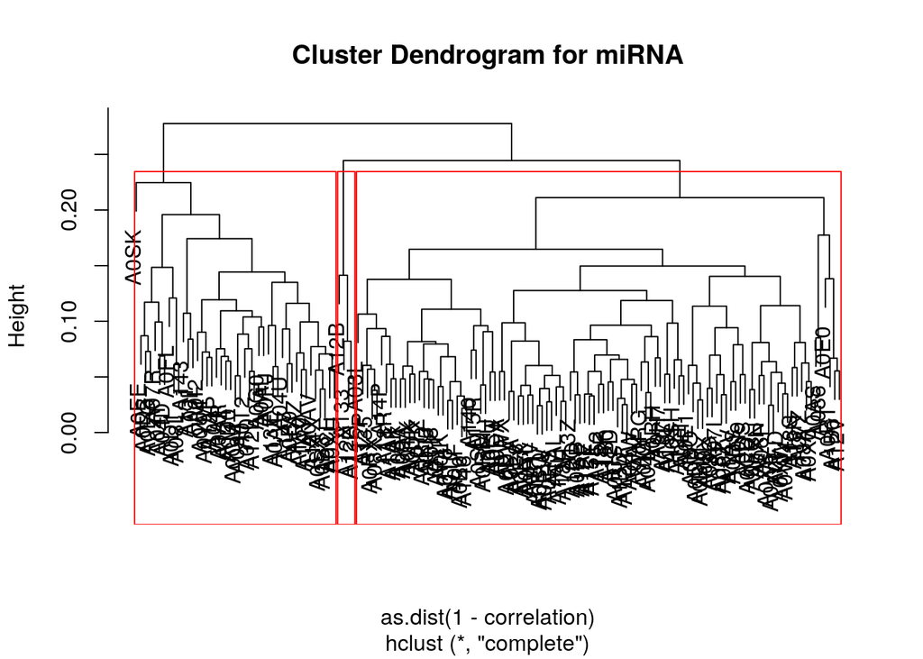

```
## [1] 0.7990157
```

```r
rnd_hcl(data$miRNA, 'Cluster Dendrogram for miRNA')
```

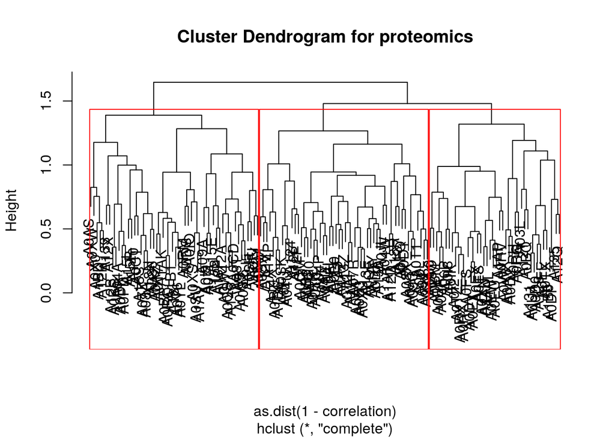

```
## [1] 0.7608054
```

```r
rnd_hcl(data$proteomics, 'Cluster Dendrogram for proteomics')
```

В среднем, результаты получились немного лучше чем для PCA, но для mRNA результат упал почти на 0.1

### Multiomics подход

Для интеграции мультиомиксных данных я использовал библиотеку mixOmics

Сначала используем метод PLS попарно для всех доступных датасетов:

```r
rnd_pls = function(data1, data2, leg){
res_pls = pls(X = t(data1), Y = t(data2), ncomp = 2)
plotIndiv(res_pls, group = Y,
          rep.space = 'XY-variate',
          pch = 19, legend = TRUE, title = leg,
          legend.title = 'Tissue', ind.names = FALSE)
k_cl = kmeans((res_pls$variates$X + res_pls$variates$Y) / 2,
        centers = 3, nstart = 100)
return(rand.index(k_cl$cluster, ref))
}
```

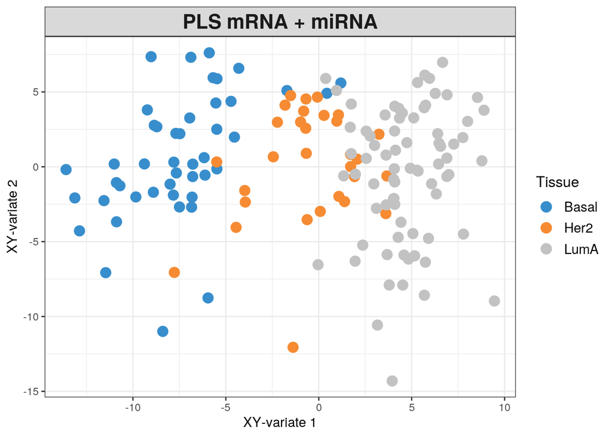

```
## [1] 0.7195526
```

```r
rnd_pls(data$mRNA, data$miRNA, 'PLS mRNA + miRNA')
```

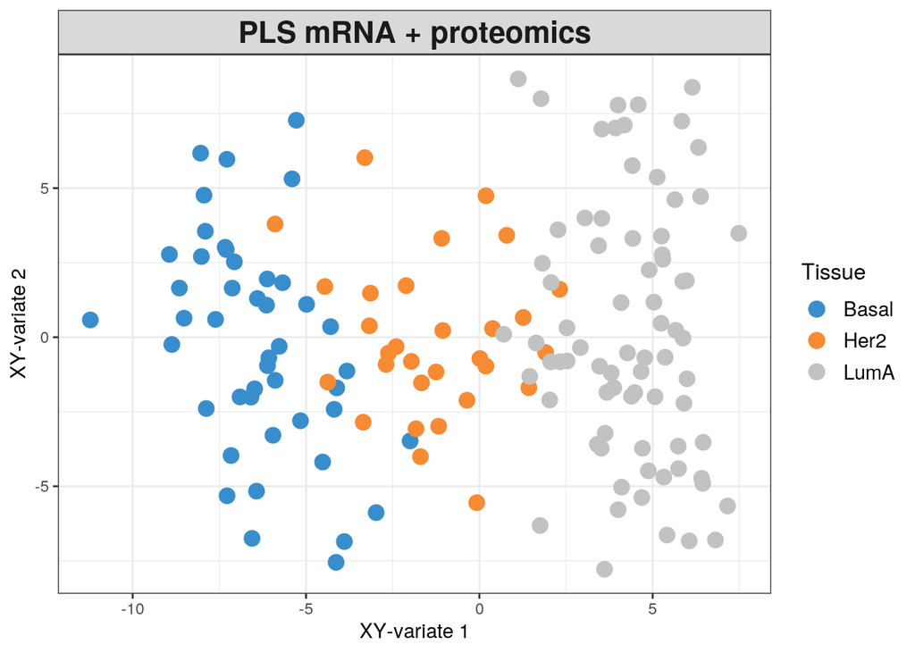

```
## [1] 0.7407606
```

```r
rnd_pls(data$mRNA, data$proteomics, 'PLS mRNA + proteomics')
```

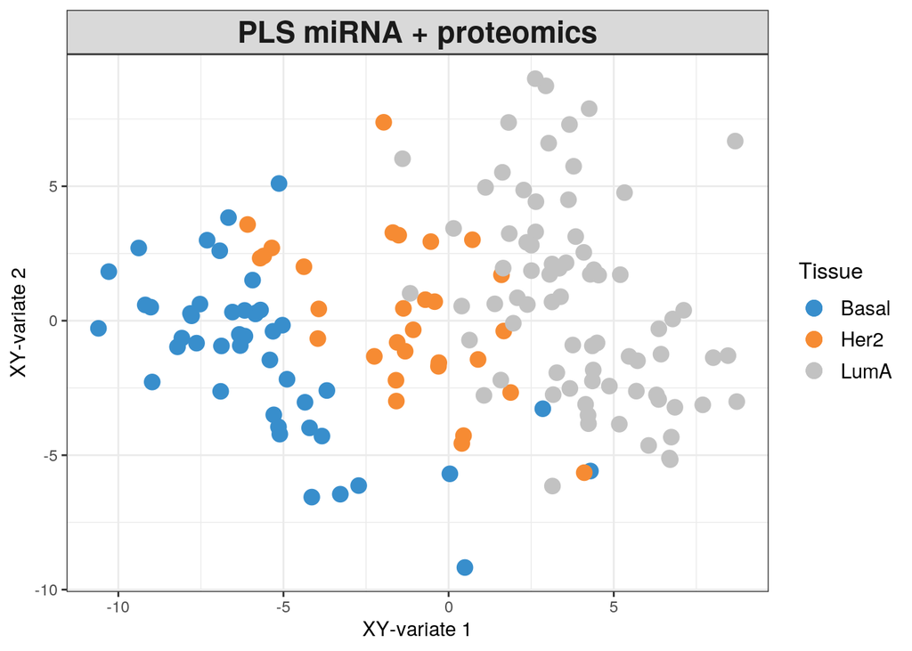

```
## [1] 0.7131096
```

```r
rnd_pls(data$miRNA, data$proteomics, 'PLS miRNA + proteomics')
```

Улучшить Rand index интегрированных данных по сравнению с неинтегрированными пока не получилось.

Теперь попробуем использовать все данные одновременно с помощью DIABLO.

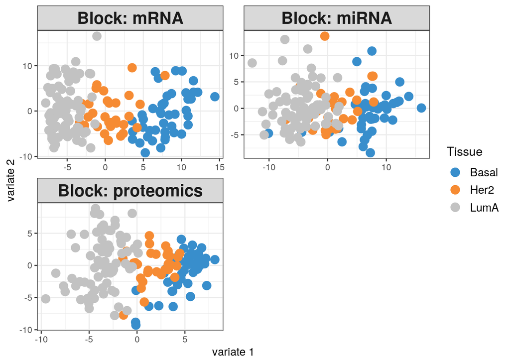

```r
X = list(mRNA = t(data$mRNA),
                   miRNA = t(data$miRNA),
                   proteomics = t(data$proteomics))

res_diablo = block.splsda(X, Y)
plotIndiv(res_diablo, pch = 19, legend = TRUE,
          legend.title = 'Tissue', ind.names = FALSE)
```

Также мы видим сильную корреляцию между датасетами:

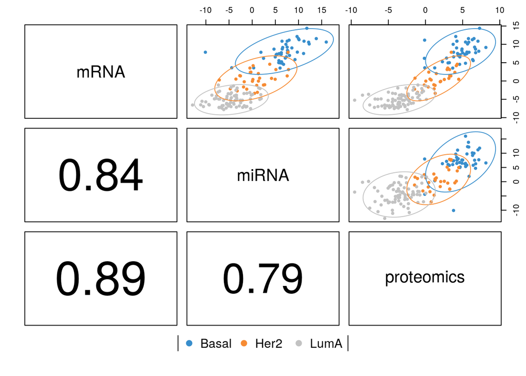

```r
plotDiablo(res_diablo, ncomp = 1)
```

Сильная корреляция немного согласуется с результатами PLS, где для комбинации mRNA + proteomics наибольший Rand index.

Возьмём среднее арифметическое всех variates и посчитаем по нему Rand index.

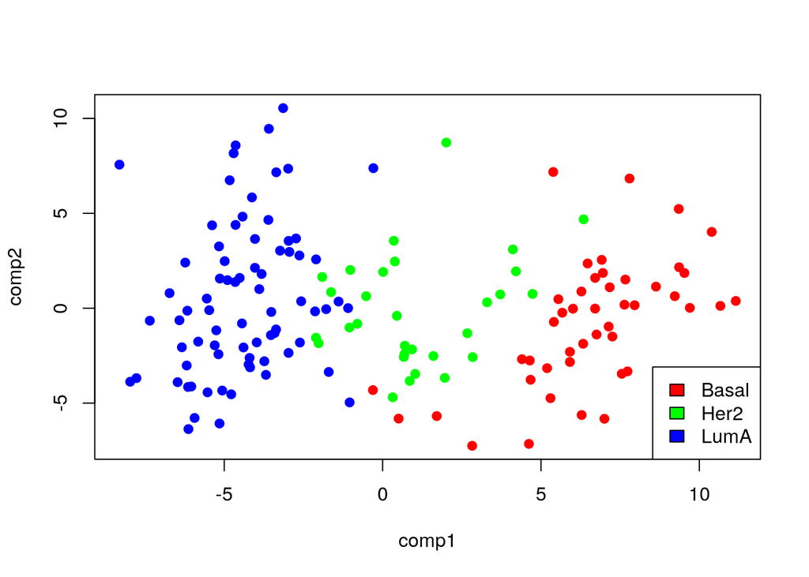

```r
all_variates = ((res_diablo$variates$mRNA + res_diablo$variates$miRNA +
                  res_diablo$variates$proteomics) / 3)
plot(all_variates, col = colours[as.integer(Y)], pch = 19)
legend(legend = levels(Y), "bottomright", fill=colours)
```

```r
k_diab = kmeans(all_variates, centers = 3, nstart = 100)
rand.index(k_diab$cluster,ref)
```

```
## [1] 0.7086353
```

Результат пока не впечатляющий. Теперь можно попробовать воспользоваться сторонними библиотеками. Первой такой библиотекой будет Rtsne который, как видно из названия реализует метод снижения размерноссти t-SNE. В ходе изменения различных параметров не было найдено хорошей комбинации.

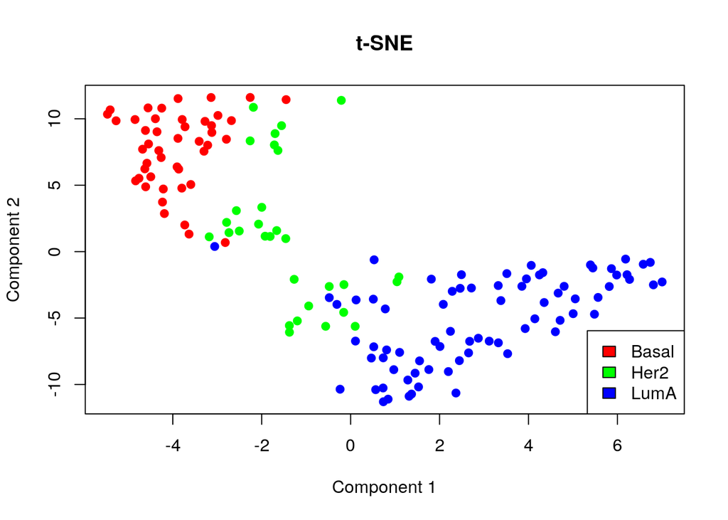

```r
library(Rtsne)
tsne = Rtsne(all_variates)
tsne_cl = kmeans(tsne$Y, centers = 3, nstart = 100)
plot(tsne$Y, col = colours[as.integer(Y)], pch = 19,
     xlab = 'Component 1', ylab = 'Component 2', main = 't-SNE')
legend(legend = levels(Y), "bottomright", fill=colours)
```

```r
rand.index(tsne_cl$cluster,ref)
```

```
## [1] 0.7348546
```

Также можно попробовать воспользоваться методом UMAP, который является более продвинутым t-SNE. В ходе вариации параметров, были найдены удачные комбинации, вот пример одной:

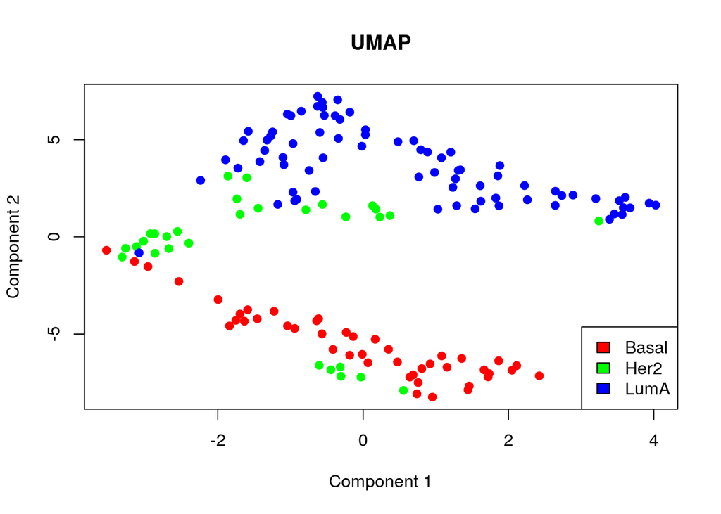

```r
library(umap)
res_umap = umap(all_variates, min_dist = 0.4, n_neighbors = 17, random_state = 13,
            n_components = 2)
umap_cl = kmeans(res_umap$layout, centers = 3, nstart = 100)
plot(res_umap$layout, col = colours[as.integer(Y)], pch = 19,
     xlab = 'Component 1', ylab = 'Component 2', main = 'UMAP')
legend(legend = levels(Y), "bottomright", fill=colours)
```

```r
rand.index(umap_cl$cluster,ref)
```

```
## [1] 0.8544072
```

### Выводы

Можно заметить достаточно часто, что визуально точки разделяются очень хорошо, но Rand index показывает не самую удовлетворительную кластеризацию для базовых методов. Тем не менее, иерархическая кластеризация смогла показать результат Rand index ≈ 0.8 для miRNA. Лучший результат показал современный UMAP и то в ходе поиска хорошего сочетания параметров.